[figure not shown]

# Mobility Metrics for Autauga, Alabama

These mobility metrics data tables are designed to help local leaders in every county and over 450 cities in the United States measure the status of and progress toward increasing upward mobility and equity in their communities.

The Urban Institute’s [Upward Mobility Framework](https://upward-mobility.urban.org/mobility-metrics-framework) identifies five essential pillars that support mobility from poverty and a set of [evidence-based predictors](https://upward-mobility.urban.org/boosting-upward-mobility-metrics-inform-local-action-second-edition) that are strongly correlated with the likelihood that a community can create conditions to boost the economic and social mobility of its residents while narrowing racial and ethnic inequities. These predictors were identified by an interdisciplinary group of [experts and refined through testing](https://upward-mobility.urban.org/methodology) with cross-sector partners. They cover diverse aspects of community, such as affordable housing, living-wage jobs, and political participation, and can be influenced by state and local policy.

Communities can use this [suite of metrics](https://upward-mobility.urban.org/boosting-upward-mobility-metrics-inform-local-action-second-edition) along with the [Planning Guide for Local Action](https://upward-mobility.urban.org/boosting-upward-mobility-planning-guide-local-action) as they work to develop a [strategic plan for upward mobility](https://upward-mobility.urban.org/mobility-action-plans) and monitor progress over time.

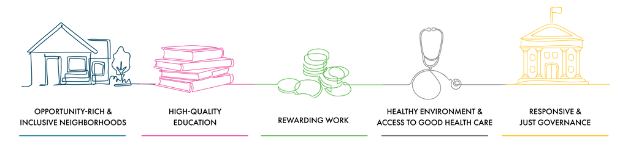

*Return [here](https://upward-mobility.urban.org/mobility-metrics-data) to select another community*

## Pillar: Opportunity-Rich & Inclusive Neighborhoods

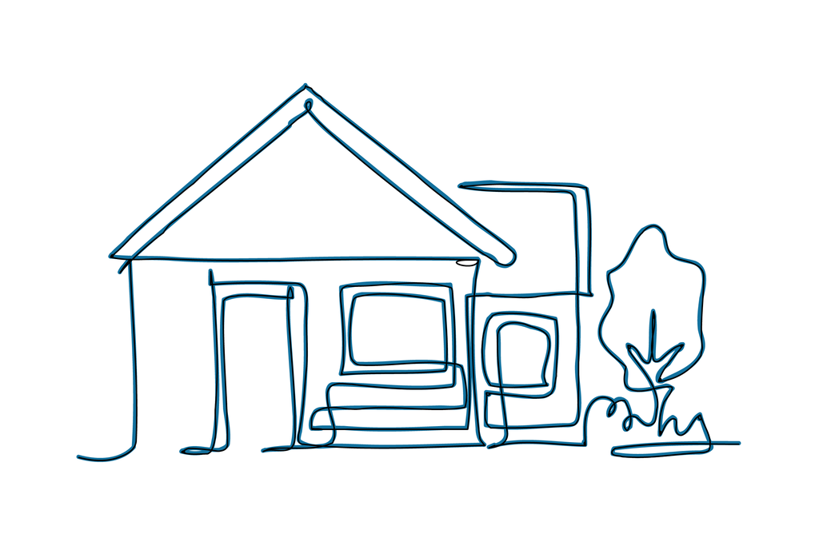

#### Predictor: Housing Affordability

**Summary**

Metric: Ratio of affordable housing units (per 100 households) with low-, very low-, and extremely low-income levels

|  | Autauga, Alabama |
| --- | --- |
| Ratio for low-income households | 169.8 |
| Ratio for very low-income households | 197.5 |
| Ratio for extremely low-income households | 209.2 |
| Data quality | Marginal |

**Source:** US Department of Housing and Urban Development Office of Policy Development and Research Fair Market Rents and Income Limits, FY 2021; US Census Bureau’s 2021 1-Year American Community Survey Public Use Microdata Sample (via IPUMS); Missouri Census Data Center Geocorr 2022: Geographic Correspondence Engine. (Time period: 2021)

**Detail**

Metric: Ratio of affordable housing units (per 100 households) with low-, very low-, and extremely low-income levels<sup>+</sup>

|  | Autauga, Alabama |
| --- | --- |
| Ratio for low-income households | 169.8 |
| Ratio for very low-income households | 197.5 |
| Ratio for extremely low-income households | 209.2 |
| Data quality | Marginal |

**Source:** US Department of Housing and Urban Development Office of Policy Development and Research Fair Market Rents and Income Limits, FY 2021; US Census Bureau’s 2021 1-Year American Community Survey Public Use Microdata Sample (via IPUMS); Missouri Census Data Center Geocorr 2022: Geographic Correspondence Engine. (Time period: 2021)  
**Notes:** This metric reports the number of housing units affordable for households with low-incomes (below 80 percent of area median income, or AMI), very low-incomes (below 50 percent of AMI), and extremely low-incomes (below 30 percent of AMI) relative to every 100 households with these income levels. Income groups are defined for a local family of 4. Housing units are defined as affordable if the monthly costs do not exceed 30 percent of a household’s income. Values above 100 suggest that there are more affordable housing units than households with those income levels. Affordability addresses whether sufficient housing units would exist if allocated solely on the basis of cost, regardless of whether they are currently occupied by a household that could afford the unit. Values below 100 suggest that on this basis the affordable stock is insufficient to meet the need. The affordable housing stock includes both vacant and occupied units. The Confidence Interval for this metric is not applicable.

**More Data**

Metric: Ratio of affordable housing units (per 100 households) with low-, very low-, and extremely low-income levels<sup>+</sup>

|  | Year | Autauga, Alabama |
| --- | --- | --- |
| Ratio for low-income households | 2021 | 169.8 |
| Ratio for very low-income households | 2021 | 197.5 |
| Ratio for extremely low-income households | 2021 | 209.2 |
| Data quality | 2021 | Marginal |
| Ratio for low-income households | 2018 | 167.6 |
| Ratio for very low-income households | 2018 | 158.2 |
| Ratio for extremely low-income households | 2018 | 153.3 |
| Data quality | 2018 | Marginal |

**Source:** US Department of Housing and Urban Development Office of Policy Development and Research Fair Market Rents and Income Limits, FY 2018 & FY 2021; US Census Bureau’s 2018 & 2021 1-Year American Community Survey Public Use Microdata Sample (via IPUMS); Missouri Census Data Center Geocorr 2022: Geographic Correspondence Engine. (Time periods: 2018 & 2021)  
**Notes:** This metric reports the number of housing units affordable for households with low-incomes (below 80 percent of area median income, or AMI), very low-incomes (below 50 percent of AMI), and extremely low-incomes (below 30 percent of AMI) relative to every 100 households with these income levels. Income groups are defined for a local family of 4. Housing units are defined as affordable if the monthly costs do not exceed 30 percent of a household’s income. Values above 100 suggest that there are more affordable housing units than households with those income levels. Affordability addresses whether sufficient housing units would exist if allocated solely on the basis of cost, regardless of whether they are currently occupied by a household that could afford the unit. Values below 100 suggest that on this basis the affordable stock is insufficient to meet the need. The affordable housing stock includes both vacant and occupied units. The Confidence Interval for this metric is not applicable.

*Visit here for more details about this predictor.*

#### Predictor: Housing stability

**Summary**

Metric: Number and share of public-school children who are ever homeless during the school year

|  | Autauga, Alabama |
| --- | --- |
| Number homeless | 57 |
| Share homeless | 0.6% |
| Data quality | Strong |

**Source:** US Department of Education Local Education Agency data, SY 2019-20 (via EDFacts Homeless Students Enrolled). (Time period: School Year 2019-20)

**Detail**

Metric: Number and share of public-school children who are ever homeless during the school year

|  | Autauga, Alabama |
| --- | --- |
| Number homeless | 57 |
| Lower/Upper bound | (57, 57) |
| Share homeless | 0.6% |
| Data quality | Strong |

**Source:** US Department of Education Local Education Agency data, SY 2019-20 (via EDFacts Homeless Students Enrolled). (Time period: School Year 2019-20)  
**Notes:** The number of homeless students is based on the number of children (age 3 through 12th grade) who are enrolled in public schools and whose primary nighttime residence at any time during a school year was a shelter, transitional housing, or awaiting foster care placement; unsheltered (e.g., a car, park, campground, temporary trailer, or abandoned building); a hotel or motel because of the lack of alternative adequate accommodations; or in housing of other people because of loss of housing, economic hardship, or a similar reason. The share is the percent of public-school students who are experiencing homelessness out of all public-school students.

**More Data**

Metric: Number and share of public-school children who are ever homeless during the school year

|  | Year | Autauga, Alabama |
| --- | --- | --- |
| Number homeless | 2019 | 57 |
| Lower/Upper bound | 2019 | (57, 57) |
| Share homeless | 2019 | 0.6% |
| Data quality | 2019 | Strong |
| Number homeless | 2018 | 58 |
| Lower/Upper bound | 2018 | (58, 58) |
| Share homeless | 2018 | 0.6% |
| Data quality | 2018 | Strong |

**Source:** US Department of Education Local Education Agency data, SY 2018-19 & SY 2019-20 (via EDFacts Homeless Students Enrolled). (Time periods: School Years 2018-19 & 2019-20)  
**Notes:** The number of homeless students is based on the number of children (age 3 through 12th grade) who are enrolled in public schools and whose primary nighttime residence at any time during a school year was a shelter, transitional housing, or awaiting foster care placement; unsheltered (e.g., a car, park, campground, temporary trailer, or abandoned building); a hotel or motel because of the lack of alternative adequate accommodations; or in housing of other people because of loss of housing, economic hardship, or a similar reason. The share is the percent of public-school students who are experiencing homelessness out of all public-school students. Data disaggregated by race/ethnicity became available for the first time in SY 2019-20.

*Visit here for more details about this predictor.*

#### Predictor: Economic inclusion

**Summary**

Metric: Share of people experiencing poverty who live in high-poverty neighborhoods

|  | Autauga, Alabama |
| --- | --- |
| % in high poverty neighborhoods | 0.0% |
| Data quality | Strong |

**Source:** US Census Bureau’s 2021 5-Year American Community Survey. (Time period: 2017-21)

**Detail**

Metric: Share of people experiencing poverty who live in high-poverty neighborhoods<sup>+</sup>

|  | Autauga, Alabama |
| --- | --- |
| % in high poverty neighborhoods | 0.0% |
| Data quality | Strong |

**Source:** US Census Bureau’s 2021 5-Year American Community Survey. (Time period: 2017-21)  
**Notes:** The share of a city’s or county’s residents living in poverty who also live in high-poverty neighborhoods (defined as census tracts). A high-poverty neighborhood is one in which over 40 percent of the residents live in poverty. People and families are classified as being in poverty if their income (before taxes and excluding capital gains or noncash benefits) is less than their poverty threshold, as defined by the US Census Bureau. Poverty thresholds vary by the size of the family and age of its members and are updated for inflation, but do not vary geographically. The Confidence Interval for this metric is not applicable.

**More Data**

Metric: Share of people experiencing poverty who live in high-poverty neighborhoods<sup>+</sup>

|  | Group | Year | Autauga, Alabama |
| --- | --- | --- | --- |
| % in high poverty neighborhoods | All | 2021 | 0.0% |
| Data quality | All | 2021 | Strong |
| % in high poverty neighborhoods | Black | 2021 | 0.0% |
| Data quality | Black | 2021 | Strong |
| % in high poverty neighborhoods | Hispanic | 2021 | 0.0% |
| Data quality | Hispanic | 2021 | Weak |
| % in high poverty neighborhoods | Other Races and Ethnicities | 2021 | 0.0% |
| Data quality | Other Races and Ethnicities | 2021 | Marginal |
| % in high poverty neighborhoods | White, Non-Hispanic | 2021 | 0.0% |
| Data quality | White, Non-Hispanic | 2021 | Strong |
| % in high poverty neighborhoods | All | 2018 | 0.0% |
| Data quality | All | 2018 | Strong |
| % in high poverty neighborhoods | Black | 2018 | 0.0% |
| Data quality | Black | 2018 | Strong |
| % in high poverty neighborhoods | Hispanic | 2018 | 0.0% |
| Data quality | Hispanic | 2018 | Weak |
| % in high poverty neighborhoods | Other Races and Ethnicities | 2018 | 0.0% |
| Data quality | Other Races and Ethnicities | 2018 | Marginal |
| % in high poverty neighborhoods | White, Non-Hispanic | 2018 | 0.0% |
| Data quality | White, Non-Hispanic | 2018 | Strong |

**Source:** US Census Bureau’s 2018 & 2021 5-Year American Community Survey. (Time periods: 2014-18 & 2017-21)  
**Notes:** The share of a city’s or county’s residents living in poverty who also live in high-poverty neighborhoods (defined as census tracts). A high-poverty neighborhood is one in which over 40 percent of the residents live in poverty. People and families are classified as being in poverty if their income (before taxes and excluding capital gains or noncash benefits) is less than their poverty threshold, as defined by the US Census Bureau. Poverty thresholds vary by the size of the family and age of its members and are updated for inflation, but do not vary geographically. ’Black’ includes Black Hispanics. ‘Other Races and Ethnicities’ includes those of races not explicitly listed and those of multiple races. Those who identify as other race or multiple races and Hispanic are counted in both the ‘Hispanic’ and ’Other Races and Ethnicities’ categories. The Confidence Interval for this metric is not applicable.

*Visit here for more details about this predictor.*

#### Predictor: Racial diversity

**Summary**

Metric: Index of people’s exposure to neighbors of different races and ethnicities

|  | Autauga, Alabama |
| --- | --- |
| % for Black, Non-Hispanic | 70.3% |
| Data quality | Strong |
| % for Hispanic | 93.0% |
| Data quality | Marginal |
| % for Other Races and Ethnicities | 92.1% |
| Data quality | Strong |
| % for White, Non-Hispanic | 24.1% |
| Data quality | Strong |

**Source:** US Census Bureau’s 2021 5-Year American Community Survey. (Time period: 2017-21)

**Detail**

Metric: Index of people’s exposure to neighbors of different races and ethnicities<sup>+</sup>

|  | Autauga, Alabama |
| --- | --- |
| % for Black, Non-Hispanic | 70.3% |
| Data quality | Strong |
| % for Hispanic | 93.0% |
| Data quality | Marginal |
| % for Other Races and Ethnicities | 92.1% |
| Data quality | Strong |
| % for White, Non-Hispanic | 24.1% |
| Data quality | Strong |

**Source:** US Census Bureau’s 2021 5-Year American Community Survey. (Time period: 2017-21)  
**Notes:** A set of metrics constructed separately for each racial/ethnic group and reports the average share of that group’s neighbors who are members of other racial/ethnic groups. This is a type of exposure index. For example, an exposure index of 90.0% in the ‘% for Black, Non-Hispanic’ row means that the average Black, non-Hispanic resident has 90.0% of their neighbors within a census tract who have a different race/ethnicity than them. The higher the value, the more exposed to people of different races/ethnicities. The Confidence Interval for this metric is not applicable.

**More Data**

Metric: Index of people’s exposure to neighbors of different races and ethnicities<sup>+</sup>

|  | Year | Autauga, Alabama |
| --- | --- | --- |
| % for Black, Non-Hispanic | 2021 | 70.3% |
| Data quality | 2021 | Strong |
| % for Hispanic | 2021 | 93.0% |
| Data quality | 2021 | Marginal |
| % for Other Races and Ethnicities | 2021 | 92.1% |
| Data quality | 2021 | Strong |
| % for White, Non-Hispanic | 2021 | 24.1% |
| Data quality | 2021 | Strong |
| % for Black, Non-Hispanic | 2018 | 74.0% |
| Data quality | 2018 | Strong |
| % for Hispanic | 2018 | 92.9% |
| Data quality | 2018 | Marginal |
| % for Other Races and Ethnicities | 2018 | 95.8% |
| Data quality | 2018 | Strong |
| % for White, Non-Hispanic | 2018 | 23.3% |
| Data quality | 2018 | Strong |

**Source:** US Census Bureau’s 2018 & 2021 5-Year American Community Survey. (Time periods: 2014-18 & 2017-21)  
**Notes:** A set of metrics constructed separately for each racial/ethnic group and reports the average share of that group’s neighbors who are members of other racial/ethnic groups. This is a type of exposure index. For example, an exposure index of 90.0% in the ‘% for Black, Non-Hispanic’ row means that the average Black, non-Hispanic resident has 90.0% of their neighbors within a census tract who have a different race/ethnicity than them. The higher the value, the more exposed to people of different races/ethnicities. The Confidence Interval for this metric is not applicable.

*Visit here for more details about this predictor.*

#### Predictor: Social Capital

**Summary**

Metric: Number of membership associations per 10,000 people

|  | Autauga, Alabama |
| --- | --- |
| Membership associations | 12.1 |
| Data quality | Strong |

**Source:** US Census Bureau’s County Business Patterns Survey, 2020 and Population Estimation Program, 2016-20; Missouri Census Data Center Geocorr 2022: Geographic Correspondence Engine. (Time period: 2016-20)

**Detail**

Metric: Number of membership associations per 10,000 people<sup>+</sup>

|  | Autauga, Alabama |
| --- | --- |
| Membership associations | 12.1 |
| Data quality | Strong |

**Source:** US Census Bureau’s County Business Patterns Survey, 2020 and Population Estimation Program, 2016-20; Missouri Census Data Center Geocorr 2022: Geographic Correspondence Engine. (Time period: 2016-20)  
**Notes:** This metric measures the number of membership associations (as self-reported by businesses and organizations) per 10,000 people in a given community. The Confidence Interval for this metric is not applicable.

*Visit here for more details about this predictor.*

#### Predictor: Social Capital

**Summary**

Metric: Ratio of Facebook friends with higher socioeconomic status to Facebook friends with lower socioeconomic status (‘economic connectedness’)

|  | Autauga, Alabama |
| --- | --- |
| Economic connectedness | 0.7 |
| Data quality | Strong |

**Source:** Opportunity Insights’ Social Capital Atlas, 2022. (Time period: 2022)

**Detail**

Metric: Ratio of Facebook friends with higher socioeconomic status to Facebook friends with lower socioeconomic status (‘economic connectedness’)<sup>+</sup>

|  | Autauga, Alabama |
| --- | --- |
| Economic connectedness | 0.7 |
| Data quality | Strong |

**Source:** Opportunity Insights’ Social Capital Atlas, 2022. (Time period: 2022)  
**Notes:** This measures the interconnectivity, by location, between people from different economic backgrounds to estimate “economic connectedness.” Specifically, the metric is twice the average share of high-socioeconomic status (SES) friends (e.g., individuals from households ranked in the top half of all income-earning households) among low-SES individuals (e.g., individuals from households ranked in the lower half of all US households based on income) in a given community. A metric value of 1 represents a community that is perfectly integrated across socioeconomic status, with half of all low-SES individuals’ friends being of high-SES. The Confidence Interval for this metric is not applicable.

*Visit here for more details about this predictor.*

#### Predictor: Transportation access

**Summary**

Metric: Transit trips index

|  | Autauga, Alabama |
| --- | --- |
| Transit trips | 18.5 |
| Data quality | Strong |

**Source:** 2016 Location Affordability Index data based on 2013-15 Illinois vehicle miles traveled data; Longitudinal Employer-Household Dynamics Origin-Destination Employment Statistics data, 2013 & 2014; US Census Bureau’s 2016 5-Year American Community Survey (via HUD AFFH data). (Time period: 2012-16)

**Detail**

Metric: Transit trips index<sup>+</sup>

|  | Autauga, Alabama |
| --- | --- |
| Transit trips | 18.5 |
| Data quality | Strong |

**Source:** 2016 Location Affordability Index data based on 2013-15 Illinois vehicle miles traveled data; Longitudinal Employer-Household Dynamics Origin-Destination Employment Statistics data, 2013 & 2014; US Census Bureau’s 2016 5-Year American Community Survey (via HUD AFFH data). (Time period: 2012-16)  
**Notes:** The number of public transit trips taken annually by a three-person single-parent family with income at 50 percent of the Area Median Income for renters. Values are percentile ranked nationally, with values ranging from 0 to 100 for each census tract. To get a value for the community, we generate a population-weighted average of census tracts within the community. The higher the value, the more likely residents utilize public transit in the community. The Confidence Interval for this metric is not applicable.

**More Data**

Metric: Transit trips index<sup>+</sup>

|  | Group | Year | Autauga, Alabama |
| --- | --- | --- | --- |
| Transit trips | All | 2016 | 18.5 |
| Data quality | All | 2016 | Strong |
| Transit trips | Majority Non-White | 2016 | 27.7 |
| Data quality | Majority Non-White | 2016 | Strong |
| Transit trips | Majority White, Non-Hispanic | 2016 | 16.4 |
| Data quality | Majority White, Non-Hispanic | 2016 | Strong |
| Transit trips | Mixed Race and Ethnicity | 2016 | 9.0 |
| Data quality | Mixed Race and Ethnicity | 2016 | Strong |

**Source:** 2016 Location Affordability Index data based on 2013-15 Illinois vehicle miles traveled data; Longitudinal Employer-Household Dynamics Origin-Destination Employment Statistics data, 2013 & 2014; US Census Bureau’s 2016 5-Year American Community Survey (via HUD AFFH data). (Time period: 2012-16)  
**Notes:** The number of public transit trips taken annually by a three-person single-parent family with income at 50 percent of the Area Median Income for renters. Values are percentile ranked nationally, with values ranging from 0 to 100 for each census tract. To get a value for the community, we generate a population-weighted average of census tracts within the community. The higher the value, the more likely residents utilize public transit in the community. ‘Majority’ means that at least 60% of residents in a census tract are members of the specified group. The Confidence Interval for this metric is not applicable.

**Summary**

Metric: Transportation cost index

|  | Autauga, Alabama |
| --- | --- |
| Transportation cost | 16.4 |
| Data quality | Strong |

**Source:** 2016 Location Affordability Index data based on 2013-15 Illinois vehicle miles traveled data; Longitudinal Employer-Household Dynamics Origin-Destination Employment Statistics data, 2013 & 2014; US Census Bureau’s 2016 5-Year American Community Survey (via HUD AFFH data). (Time period: 2012-16)

**Detail**

Metric: Transportation cost index<sup>+</sup>

|  | Autauga, Alabama |
| --- | --- |
| Transportation cost | 16.4 |
| Data quality | Strong |

**Source:** 2016 Location Affordability Index data based on 2013-15 Illinois vehicle miles traveled data; Longitudinal Employer-Household Dynamics Origin-Destination Employment Statistics data, 2013 & 2014; US Census Bureau’s 2016 5-Year American Community Survey (via HUD AFFH data). (Time period: 2012-16)  
**Notes:** Reflects local transportation costs as a share of renters’ incomes. It accounts for both transit and cars. This index is based on estimates of transportation costs for a family that meets the following description: a three-person, single-parent family with income at 50 percent of the median income for renters for the region (i.e., core-based statistical area). Values are inverted and percentile ranked nationally, with values ranging from 0 to 100. The higher the value, the lower the cost of transportation in that neighborhood. The Confidence Interval for this metric is not applicable.

**More Data**

Metric: Transportation cost index<sup>+</sup>

|  | Group | Year | Autauga, Alabama |
| --- | --- | --- | --- |
| Transportation cost | All | 2016 | 16.4 |
| Data quality | All | 2016 | Strong |
| Transportation cost | Majority Non-White Tracts | 2016 | 15.3 |
| Data quality | Majority Non-White Tracts | 2016 | Strong |
| Transportation cost | Majority White, Non-Hispanic Tracts | 2016 | 16.9 |
| Data quality | Majority White, Non-Hispanic Tracts | 2016 | Strong |
| Transportation cost | No Majority Race/Ethnicity Tracts | 2016 | 13.0 |
| Data quality | No Majority Race/Ethnicity Tracts | 2016 | Strong |

**Source:** 2016 Location Affordability Index data based on 2013-15 Illinois vehicle miles traveled data; Longitudinal Employer-Household Dynamics Origin-Destination Employment Statistics data, 2013 & 2014; US Census Bureau’s 2016 5-Year American Community Survey (via HUD AFFH data). (Time period: 2012-16)  
**Notes:** Reflects local transportation costs as a share of renters’ incomes. It accounts for both transit and cars. This index is based on estimates of transportation costs for a family that meets the following description: a three-person, single-parent family with income at 50 percent of the median income for renters for the region (i.e., core-based statistical area). Values are inverted and percentile ranked nationally, with values ranging from 0 to 100. The higher the value, the lower the cost of transportation in that neighborhood. ’Majority’ means that at least 60% of residents in a census tract are members of the specified group. The Confidence Interval for this metric is not applicable.

*Visit here for more details about this predictor.*

## Pillar: High-Quality Education

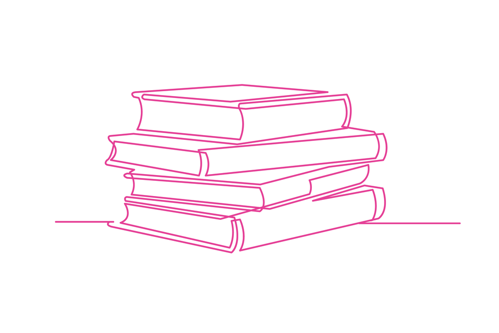

#### Predictor: Access to preschool

**Summary**

Metric: Share of (3- to 4-year-old) children enrolled in nursery school or preschool

|  | Autauga, Alabama |
| --- | --- |
| % Pre-kindergarten | 52.7% |
| Data quality | Weak |

**Source:** US Census Bureau’s 2021 1-Year American Community Survey Public Use Microdata Sample (via IPUMS); Missouri Census Data Center Geocorr 2022: Geographic Correspondence Engine. (Time period: 2021)

**Detail**

Metric: Share of (3- to 4-year-old) children enrolled in nursery school or preschool<sup>+</sup>

|  | Autauga, Alabama |
| --- | --- |
| % Pre-kindergarten | 52.7% |
| Data quality | Weak |

**Source:** US Census Bureau’s 2021 1-Year American Community Survey Public Use Microdata Sample (via IPUMS); Missouri Census Data Center Geocorr 2022: Geographic Correspondence Engine. (Time period: 2021)  
**Notes:** The share of a community’s children aged three to four who are enrolled in nursery or preschool. The Confidence Interval for this metric is not applicable.

**More Data**

Metric: Share of (3- to 4-year-old) children enrolled in nursery school or preschool<sup>+</sup>

|  | Group | Year | Autauga, Alabama |
| --- | --- | --- | --- |
| % Pre-kindergarten | All | 2021 | 28.7% |
| Data quality | All | 2021 | Marginal |
| % Pre-kindergarten | Black, Non-Hispanic | 2021 | 21.3% |
| Data quality | Black, Non-Hispanic | 2021 | Weak |
| % Pre-kindergarten | Hispanic | 2021 | NA |
| Data quality | Hispanic | 2021 | NA |
| % Pre-kindergarten | Other Races and Ethnicities | 2021 | NA |
| Data quality | Other Races and Ethnicities | 2021 | NA |
| % Pre-kindergarten | White, Non-Hispanic | 2021 | 30.4% |
| Data quality | White, Non-Hispanic | 2021 | Weak |
| % Pre-kindergarten | All | 2018 | 19.4% |
| Data quality | All | 2018 | Marginal |
| % Pre-kindergarten | Black, Non-Hispanic | 2018 | 36.3% |
| Data quality | Black, Non-Hispanic | 2018 | Weak |
| % Pre-kindergarten | Hispanic | 2018 | NA |
| Data quality | Hispanic | 2018 | NA |
| % Pre-kindergarten | Other Races and Ethnicities | 2018 | NA |
| Data quality | Other Races and Ethnicities | 2018 | NA |
| % Pre-kindergarten | White, Non-Hispanic | 2018 | 39.0% |
| Data quality | White, Non-Hispanic | 2018 | Weak |

**Source:** US Census Bureau’s 2018 & 2021 5-Year American Community Survey (via IPUMS); Missouri Census Data Center Geocorr 2022: Geographic Correspondence Engine. (Time period: 2014-18 & 2017-21)  
**Notes:** The share of a community’s children aged three to four who are enrolled in nursery or preschool. The Confidence Interval for this metric is not applicable.

*Visit here for more details about this predictor.*

#### Predictor: Effective public education

**Summary**

Metric: Average per grade change in English Language Arts achievement between third and eighth grades

|  | Autauga, Alabama |
| --- | --- |
| Annual ELA achievement | 0.96 |
| Data quality | Strong |

**Source:** Stanford Education Data Archive, SY 2017-18 (Version 4.1; Reardon, S. F. et al. 2021; retrieved from http://purl.stanford.edu/db586ns4974) (Time period: School Year 2017-18)

**Detail**

Metric: Average per grade change in English Language Arts achievement between third and eighth grades

|  | Autauga, Alabama |
| --- | --- |
| Annual ELA achievement | 0.96 |
| Lower/Upper bound | (0.84, 1.08) |
| Data quality | Strong |

**Source:** Stanford Education Data Archive, SY 2017-18 (Version 4.1; Reardon, S. F. et al. 2021; retrieved from http://purl.stanford.edu/db586ns4974) (Time period: School Year 2017-18)  
**Notes:** The average per year improvement in English/language arts (reading comprehension and written expression) among public school students between the third and eighth grades. Assessments are normalized such that a typical learning growth is roughly 1 grade level per year. ‘1’ indicates a community is learning at an average rate; below 1 is slower than average, and above 1 is faster than average.

**More Data**

Metric: Average per grade change in English Language Arts achievement between third and eighth grades

|  | Group | Year | Autauga, Alabama |
| --- | --- | --- | --- |
| Annual ELA achievement | All | 2017 | 0.96 |
| Lower/Upper bound | All | 2017 | (0.84, 1.08) |
| Data quality | All | 2017 | Strong |
| Annual ELA achievement | Black, Non-Hispanic | 2017 | 1.06 |
| Lower/Upper bound | Black, Non-Hispanic | 2017 | (0.88, 1.25) |
| Data quality | Black, Non-Hispanic | 2017 | Strong |
| Annual ELA achievement | Hispanic | 2017 | 0.72 |
| Lower/Upper bound | Hispanic | 2017 | (-0.34, 1.78) |
| Data quality | Hispanic | 2017 | Weak |
| Annual ELA achievement | Other Races and Ethnicities | 2017 | NA |
| Lower/Upper bound | Other Races and Ethnicities | 2017 | NA |
| Data quality | Other Races and Ethnicities | 2017 | NA |
| Annual ELA achievement | White, Non-Hispanic | 2017 | 1 |
| Lower/Upper bound | White, Non-Hispanic | 2017 | (0.88, 1.12) |
| Data quality | White, Non-Hispanic | 2017 | Strong |
| Annual ELA achievement | All | 2016 | 0.95 |
| Lower/Upper bound | All | 2016 | (0.84, 1.06) |
| Data quality | All | 2016 | Strong |
| Annual ELA achievement | Black, Non-Hispanic | 2016 | 0.97 |
| Lower/Upper bound | Black, Non-Hispanic | 2016 | (0.8, 1.15) |
| Data quality | Black, Non-Hispanic | 2016 | Strong |
| Annual ELA achievement | Hispanic | 2016 | 0.06 |
| Lower/Upper bound | Hispanic | 2016 | (-1.33, 1.45) |
| Data quality | Hispanic | 2016 | Weak |
| Annual ELA achievement | Other Races and Ethnicities | 2016 | NA |
| Lower/Upper bound | Other Races and Ethnicities | 2016 | NA |
| Data quality | Other Races and Ethnicities | 2016 | NA |
| Annual ELA achievement | White, Non-Hispanic | 2016 | 0.94 |
| Lower/Upper bound | White, Non-Hispanic | 2016 | (0.83, 1.06) |
| Data quality | White, Non-Hispanic | 2016 | Strong |

**Source:** Stanford Education Data Archive, SY 2016-17 & SY 2017-18 (Version 4.1; Reardon, S. F. et al. 2021; retrieved from http://purl.stanford.edu/db586ns4974) (Time period: School Years 2016-17 & 2017-18)  
**Notes:** The average per year improvement in English/language arts (reading comprehension and written expression) among public school students between the third and eighth grades. Assessments are normalized such that a typical learning growth is roughly 1 grade level per year. ‘1’ indicates a community is learning at an average rate; below 1 is slower than average, and above 1 is faster than average. Research suggests that annual improvement in English for Hispanic children will exceed those of White, Non-Hispanic children because Hispanic children, on average, start with lower levels of English language skills and can improve more quickly than children with higher baseline skills. Research suggests that annual improvement in English for students in low-income or economically disadvantaged households will exceed those of non-economically disadvantaged households because students in less advantaged households, on average, start with lower levels of English language skills and can improve more quickly than children with higher baseline skills. ‘Low-income’ means students are determined to be eligible for their schools’ free and reduced-price meals under the National School Lunch Program.

Metric: Average per grade change in English Language Arts achievement between third and eighth grades

|  | Group | Year | Autauga, Alabama |
| --- | --- | --- | --- |
| Annual ELA achievement | All | 2017 | 0.96 |
| Lower/Upper bound | All | 2017 | (0.84, 1.08) |
| Data quality | All | 2017 | Strong |
| Annual ELA achievement | Low Income | 2017 | 0.96 |
| Lower/Upper bound | Low Income | 2017 | (0.8, 1.12) |
| Data quality | Low Income | 2017 | Strong |
| Annual ELA achievement | Not Low-Income | 2017 | 0.98 |
| Lower/Upper bound | Not Low-Income | 2017 | (0.84, 1.12) |
| Data quality | Not Low-Income | 2017 | Strong |
| Annual ELA achievement | All | 2016 | 0.95 |
| Lower/Upper bound | All | 2016 | (0.84, 1.06) |
| Data quality | All | 2016 | Strong |
| Annual ELA achievement | Low Income | 2016 | 0.93 |
| Lower/Upper bound | Low Income | 2016 | (0.79, 1.07) |
| Data quality | Low Income | 2016 | Strong |
| Annual ELA achievement | Not Low-Income | 2016 | 0.94 |
| Lower/Upper bound | Not Low-Income | 2016 | (0.8, 1.09) |
| Data quality | Not Low-Income | 2016 | Strong |

**Source:** Stanford Education Data Archive, SY 2016-17 & SY 2017-18 (Version 4.1; Reardon, S. F. et al. 2021; retrieved from http://purl.stanford.edu/db586ns4974) (Time period: School Years 2016-17 & 2017-18)  
**Notes:** The average per year improvement in English/language arts (reading comprehension and written expression) among public school students between the third and eighth grades. Assessments are normalized such that a typical learning growth is roughly 1 grade level per year. ‘1’ indicates a community is learning at an average rate; below 1 is slower than average, and above 1 is faster than average. Research suggests that annual improvement in English for Hispanic children will exceed those of White, Non-Hispanic children because Hispanic children, on average, start with lower levels of English language skills and can improve more quickly than children with higher baseline skills. Research suggests that annual improvement in English for students in low-income or economically disadvantaged households will exceed those of non-economically disadvantaged households because students in less advantaged households, on average, start with lower levels of English language skills and can improve more quickly than children with higher baseline skills. ‘Low-income’ means students are determined to be eligible for their schools’ free and reduced-price meals under the National School Lunch Program.

*Visit here for more details about this predictor.*

#### Predictor: School economic diversity

**Summary**

Metric: Share of students attending high-poverty schools, by student race/ethnicity

|  | Autauga, Alabama |
| --- | --- |
| % for White, non-Hispanic | 40.2% |
| Data quality | Strong |
| % for Black, non-Hispanic | 40.0% |
| Data quality | Strong |
| % for Hispanic | 33.3% |
| Data quality | Strong |

**Source:** National Center for Education Statistics Common Core of Data, SY 2018-19; Urban Institute’s Modeled Estimates of Poverty in Schools (via Education Data Portal v. 0.17.0, Urban Institute, under ODC Attribution License). (Time period: School Year 2018-19)

**Detail**

Metric: Share of students attending high-poverty schools, by student race/ethnicity<sup>+</sup>

|  | Autauga, Alabama |
| --- | --- |
| % for White, non-Hispanic | 40.2% |
| Data quality | Strong |
| % for Black, non-Hispanic | 40.0% |
| Data quality | Strong |
| % for Hispanic | 33.3% |
| Data quality | Strong |

**Source:** National Center for Education Statistics Common Core of Data, SY 2018-19; Urban Institute’s Modeled Estimates of Poverty in Schools (via Education Data Portal v. 0.17.0, Urban Institute, under ODC Attribution License). (Time period: School Year 2018-19)  
**Notes:** This set of metrics is constructed separately for each racial/ethnic group and reports the share of students attending schools in which over 20 percent of students come from households earning at or below 100% of the Federal Poverty Level. The Confidence Interval for this metric is not applicable.

**More data**

Metric: Share of students attending high-poverty schools, by student race/ethnicity<sup>+</sup>

|  | Year | Autauga, Alabama |
| --- | --- | --- |
| % for White, non-Hispanic | 2018 | 40.2% |
| Data quality | 2018 | Strong |
| % for Black, non-Hispanic | 2018 | 40.0% |
| Data quality | 2018 | Strong |
| % for Hispanic | 2018 | 33.3% |
| Data quality | 2018 | Strong |
| % for White, non-Hispanic | 2014 | 32.5% |
| Data quality | 2014 | Strong |
| % for Black, non-Hispanic | 2014 | 36.4% |
| Data quality | 2014 | Strong |
| % for Hispanic | 2014 | 23.9% |
| Data quality | 2014 | Strong |

*Visit here for more details about this predictor.*

#### Predictor: Preparation for college

**Summary**

Metric: Share of 19- and 20-year-olds with a high school degree

|  | Autauga, Alabama |
| --- | --- |
| % HS degree | 65.8% |
| Data quality | Weak |

**Source:** US Census Bureau’s 2021 1-Year American Community Survey Public Use Microdata Sample (via IPUMS); Missouri Census Data Center Geocorr 2022: Geographic Correspondence Engine. (Time period: 2021)

**Detail**

Metric: Share of 19- and 20-year-olds with a high school degree<sup>+</sup>

|  | Autauga, Alabama |
| --- | --- |
| % HS degree | 65.8% |
| Data quality | Weak |

**Source:** US Census Bureau’s 2021 1-Year American Community Survey Public Use Microdata Sample (via IPUMS); Missouri Census Data Center Geocorr 2022: Geographic Correspondence Engine. (Time period: 2021)  
**Notes:** The share of 19- and 20-year-olds in a community who have a high school degree. The Confidence Interval for this metric is not applicable.

**More Data**

Metric: Share of 19- and 20-year-olds with a high school degree<sup>+</sup>

|  | Group | Year | Autauga, Alabama |
| --- | --- | --- | --- |
| % HS degree | All | 2021 | 80.9% |
| Data quality | All | 2021 | Marginal |
| % HS degree | Black, Non-Hispanic | 2021 | NA |
| Data quality | Black, Non-Hispanic | 2021 | NA |
| % HS degree | Hispanic | 2021 | NA |
| Data quality | Hispanic | 2021 | NA |
| % HS degree | Other Races and Ethnicities | 2021 | NA |
| Data quality | Other Races and Ethnicities | 2021 | NA |
| % HS degree | White, Non-Hispanic | 2021 | 93.9% |
| Data quality | White, Non-Hispanic | 2021 | Weak |
| % HS degree | All | 2018 | 85.3% |
| Data quality | All | 2018 | Weak |
| % HS degree | Black, Non-Hispanic | 2018 | NA |
| Data quality | Black, Non-Hispanic | 2018 | NA |
| % HS degree | Hispanic | 2018 | NA |
| Data quality | Hispanic | 2018 | NA |
| % HS degree | Other Races and Ethnicities | 2018 | NA |
| Data quality | Other Races and Ethnicities | 2018 | NA |
| % HS degree | White, Non-Hispanic | 2018 | 91.7% |
| Data quality | White, Non-Hispanic | 2018 | Weak |

**Source:** US Census Bureau’s 2018 & 2021 5-Year American Community Survey Public Use Microdata Sample (via IPUMS); Missouri Census Data Center Geocorr 2022: Geographic Correspondence Engine. (Time period: 2014-18 & 2017-21)  
**Notes:** The share of 19- and 20-year-olds in a community who have a high school degree. The Confidence Interval for this metric is not applicable.

*Visit here for more details about this predictor.*

#### Predictor: Digital access

**Summary**

Metric: Share of people in households with broadband access in the home

|  | Autauga, Alabama |
| --- | --- |
| % Digital access | 88.0% |
| Data quality | Strong |

**Source:** US Census Bureau’s 2021 5-Year American Community Survey. (Time period: 2017-2021)

**Detail**

Metric: Share of people in households with broadband access in the home*

|  | Autauga, Alabama |
| --- | --- |
| % Digital access | 88.0% |
| Data quality | Strong |

**Source:** US Census Bureau’s 2021 5-Year American Community Survey. (Time period: 2017-2021)  
**Notes:** This metric represents the share of people in households with access to broadband in their home. The Confidence Interval for this metric is not available at this time.

**More Data**

Metric: Share of people in households with broadband access in the home*

|  | Group | Year | Autauga, Alabama |
| --- | --- | --- | --- |
| % Digital access | All | 2021 | 88.0% |
| Data quality | All | 2021 | Strong |
| % Digital access | Black | 2021 | 76.5% |
| Data quality | Black | 2021 | Strong |
| % Digital access | Hispanic | 2021 | 65.1% |
| Data quality | Hispanic | 2021 | Weak |
| % Digital access | Other Races and Ethnicities | 2021 | 88.6% |
| Data quality | Other Races and Ethnicities | 2021 | Marginal |
| % Digital access | White | 2021 | 91.0% |
| Data quality | White | 2021 | Strong |

**Source:** US Census Bureau’s 2021 5-Year American Community Survey. (Time period: 2017-2021)  
**Notes:** This metric represents the share of people in households with access to broadband in their home. The Confidence Interval for this metric is not available at this time.

*Visit here for more details about this predictor.*

## Pillar: Rewarding Work

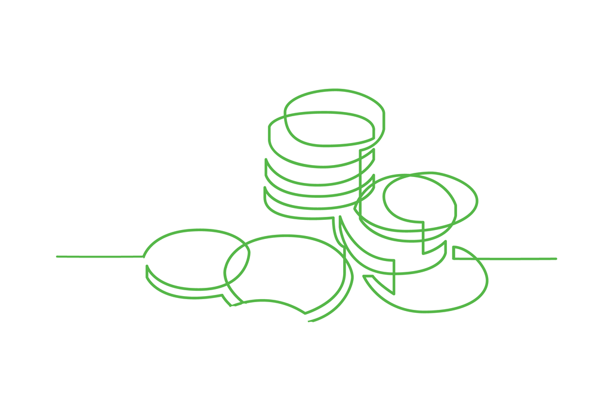

#### Predictor: Employment Opportunities

**Summary**

Metric: Employment-to-population ratio for adults ages 25 to 54

|  | Autauga, Alabama |
| --- | --- |
| Employment to population ratio | 77.5% |
| Data quality | Weak |

**Source:** US Census Bureau’s 2021 1-Year American Community Survey Public Use Microdata Sample (PUMS) (via IPUMS); Missouri Census Data Center Geocorr 2022: Geographic Correspondence Engine. (Time period: 2021)

**Detail**

Metric: Employment-to-population ratio for adults ages 25 to 54<sup>+</sup>

|  | Autauga, Alabama |
| --- | --- |
| Employment to population ratio | 77.5% |
| Data quality | Weak |

**Source:** US Census Bureau’s 2021 1-Year American Community Survey Public Use Microdata Sample (PUMS) (via IPUMS); Missouri Census Data Center Geocorr 2022: Geographic Correspondence Engine. (Time period: 2021)  
**Notes:** The share of adults between the ages of 25 and 54 in a given community who are employed. The Confidence Interval for this metric is not applicable.

**More Data**

Metric: Employment-to-population ratio for adults ages 25 to 54<sup>+</sup>

|  | Group | Year | Autauga, Alabama |
| --- | --- | --- | --- |
| Employment to population ratio | All | 2021 | 76.3% |
| Data quality | All | 2021 | Weak |
| Employment to population ratio | Black, Non-Hispanic | 2021 | 70.9% |
| Data quality | Black, Non-Hispanic | 2021 | Weak |
| Employment to population ratio | Hispanic | 2021 | NA |
| Data quality | Hispanic | 2021 | NA |
| Employment to population ratio | Other Races and Ethnicities | 2021 | NA |
| Data quality | Other Races and Ethnicities | 2021 | NA |
| Employment to population ratio | White, Non-Hispanic | 2021 | 78.5% |
| Data quality | White, Non-Hispanic | 2021 | Weak |
| Employment to population ratio | All | 2018 | 73.3% |
| Data quality | All | 2018 | Weak |
| Employment to population ratio | Black, Non-Hispanic | 2018 | 67.2% |
| Data quality | Black, Non-Hispanic | 2018 | Weak |
| Employment to population ratio | Hispanic | 2018 | NA |
| Data quality | Hispanic | 2018 | NA |
| Employment to population ratio | Other Races and Ethnicities | 2018 | NA |
| Data quality | Other Races and Ethnicities | 2018 | NA |
| Employment to population ratio | White, Non-Hispanic | 2018 | 75.3% |
| Data quality | White, Non-Hispanic | 2018 | Weak |

**Source:** US Census Bureau’s 2018 & 2021 5-Year American Community Survey Public Use Microdata Sample (via IPUMS); Missouri Census Data Center Geocorr 2022: Geographic Correspondence Engine. (Time period: 2014-18 & 2017-21)  
**Notes:** The share of adults between the ages of 25 and 54 in a given community who are employed. The Confidence Interval for this metric is not applicable.

*Visit here for more details about this predictor.*

#### Predictor: Access to jobs paying a living wage

**Summary**

Metric: Ratio of pay on an average job to the cost of living

|  | Autauga, Alabama |
| --- | --- |
| Ratio of pay to living wage | 0.6 |
| Data quality | Strong |

**Source:** US Bureau of Labor Statistics Quarterly Census of Employment and Wages (QCEW) data, 2021; Massachusetts Institute of Technology Living Wage Calculator, 2022. (Time period: 2021)

**Detail**

Metric: Ratio of pay on an average job to the cost of living<sup>+</sup>

|  | Autauga, Alabama |
| --- | --- |
| Ratio of pay to living wage | 0.6 |
| Data quality | Strong |

**Source:** US Bureau of Labor Statistics Quarterly Census of Employment and Wages (QCEW) data, 2021; Massachusetts Institute of Technology Living Wage Calculator, 2022. (Time period: 2021)  
**Notes:** What an average job pays relative to the cost of living in a particular area. The metric is computed by dividing the average earnings for a job in an area by the cost of meeting a family of three’s (for a 1 adult and 2 child household) basic expenses in that area. Ratio values greater than 1 indicate that the average job pays more than the cost of living, while values less than 1 suggest the average job pays less than the cost of living. For the 2021 metric, we were only able to access the 2022 Living Wage data. We deflated the 2022 data to 2021 using the consumer price index (for all urban consumers), for a correct comparison with the 2021 QCEW. The Confidence Interval for this metric is not applicable.

**More Data**

Metric: Ratio of pay on an average job to the cost of living<sup>+</sup>

|  | Year | Autauga, Alabama |
| --- | --- | --- |
| Ratio of pay to living wage | 2021 | 0.60 |
| Data quality | 2021 | Strong |
| Ratio of pay to living wage | 2018 | 0.67 |
| Data quality | 2018 | Strong |

**Source:** US Bureau of Labor Statistics Quarterly Census of Employment and Wages (QCEW) data, 2018 & 2021; Massachusetts Institute of Technology Living Wage Calculator, 2018 & 2022. (Time period: 2018 & 2021)  
**Notes:** What an average job pays relative to the cost of living in a particular area. The metric is computed by dividing the average earnings for a job in an area by the cost of meeting a family of three’s (for a 1 adult and 2 child household) basic expenses in that area. Ratio values greater than 1 indicate that the average job pays more than the cost of living, while values less than 1 suggest the average job pays less than the cost of living. For the 2021 metric, we were only able to access the 2022 Living Wage data. We deflated the 2022 data to 2021 using the consumer price index (for all urban consumers), for a correct comparison with the 2021 QCEW. The Confidence Interval for this metric is not applicable.

*Visit here for more details about this predictor.*

#### Predictor: Opportunities for Income

**Summary**

Metric: Household income at the 20th, 50th, and 80th percentiles

|  | Autauga, Alabama |
| --- | --- |
| 20th Percentile | $28,509 |
| 50th Percentile | $60,719 |
| 80th Percentile | $113,796 |
| Data quality | Weak |

**Source:** US Census Bureau’s 2021 1-Year American Community Survey Public Use Microdata Sample (via IPUMS); Missouri Census Data Center Geocorr 2022: Geographic Correspondence Engine. (Time Period: 2021)

**Detail**

Metric: Household income at the 20th, 50th, and 80th percentiles*

|  | Autauga, Alabama |
| --- | --- |
| 20th Percentile | $28,509 |
| 50th Percentile | $60,719 |
| 80th Percentile | $113,796 |
| Data quality | Weak |

**Source:** US Census Bureau’s 2021 1-Year American Community Survey Public Use Microdata Sample (via IPUMS); Missouri Census Data Center Geocorr 2022: Geographic Correspondence Engine. (Time Period: 2021)  
**Notes:** To identify income percentiles, all households are ranked by income from lowest to highest. The income level threshold for the poorest 20 percent of households is the value at the 20th percentile. The 50th percentile income threshold indicates the median, with half of households earning less and half of households earning more. The income level threshold for the richest 20 percent of households is the value at the 80th percentile. The difference in income between households at the 20th percentile and the 80th percentile illustrates the level of local economic inequality. The Confidence Interval for this metric is not available at this time.

**More Data**

Metric: Household income at the 20th, 50th, and 80th percentiles*

|  | Group | Year | Autauga, Alabama |
| --- | --- | --- | --- |
| 20th Percentile | All | 2021 | $26,119 |
| 50th Percentile | All | 2021 | $62,952 |
| 80th Percentile | All | 2021 | $115,971 |
| Data quality | All | 2021 | Weak |
| 20th Percentile | Black, Non-Hispanic | 2021 | $17,068 |
| 50th Percentile | Black, Non-Hispanic | 2021 | $42,266 |
| 80th Percentile | Black, Non-Hispanic | 2021 | $88,465 |
| Data quality | Black, Non-Hispanic | 2021 | Weak |
| 20th Percentile | Hispanic | 2021 | NA |
| 50th Percentile | Hispanic | 2021 | NA |
| 80th Percentile | Hispanic | 2021 | NA |
| Data quality | Hispanic | 2021 | NA |
| 20th Percentile | Other Races and Ethnicities | 2021 | NA |
| 50th Percentile | Other Races and Ethnicities | 2021 | NA |
| 80th Percentile | Other Races and Ethnicities | 2021 | NA |
| Data quality | Other Races and Ethnicities | 2021 | NA |
| 20th Percentile | White, Non-Hispanic | 2021 | $34,185 |
| 50th Percentile | White, Non-Hispanic | 2021 | $73,229 |
| 80th Percentile | White, Non-Hispanic | 2021 | $125,314 |
| Data quality | White, Non-Hispanic | 2021 | Weak |
| 20th Percentile | All | 2018 | $21,412 |
| 50th Percentile | All | 2018 | $55,722 |
| 80th Percentile | All | 2018 | $106,938 |
| Data quality | All | 2018 | Weak |
| 20th Percentile | Black, Non-Hispanic | 2018 | $12,411 |
| 50th Percentile | Black, Non-Hispanic | 2018 | $36,176 |
| 80th Percentile | Black, Non-Hispanic | 2018 | $81,237 |
| Data quality | Black, Non-Hispanic | 2018 | Weak |
| 20th Percentile | Hispanic | 2018 | NA |
| 50th Percentile | Hispanic | 2018 | NA |
| 80th Percentile | Hispanic | 2018 | NA |
| Data quality | Hispanic | 2018 | NA |
| 20th Percentile | Other Races and Ethnicities | 2018 | NA |
| 50th Percentile | Other Races and Ethnicities | 2018 | NA |
| 80th Percentile | Other Races and Ethnicities | 2018 | NA |
| Data quality | Other Races and Ethnicities | 2018 | NA |
| 20th Percentile | White, Non-Hispanic | 2018 | $27,816 |
| 50th Percentile | White, Non-Hispanic | 2018 | $63,544 |
| 80th Percentile | White, Non-Hispanic | 2018 | $114,825 |
| Data quality | White, Non-Hispanic | 2018 | Weak |

**Source:** US Census Bureau’s 2018 & 2021 5-Year American Community Survey Public Use Microdata Sample (via IPUMS); Missouri Census Data Center Geocorr 2022: Geographic Correspondence Engine. (Time Periods: 2014-18 & 2017-21)  
**Notes:** To identify income percentiles, all households are ranked by income from lowest to highest. The income level threshold for the poorest 20 percent of households is the value at the 20th percentile. The 50th percentile income threshold indicates the median, with half of households earning less and half of households earning more. The income level threshold for the richest 20 percent of households is the value at the 80th percentile. The difference in income between households at the 20th percentile and the 80th percentile illustrates the level of local economic inequality. The Confidence Interval for this metric is not available at this time.

*Visit here for more details about this predictor.*

#### Predictor: Financial security

**Summary**

Metric: Share with debt in collections

|  | Autauga, Alabama |
| --- | --- |
| % with debt | 30.0% |
| Data quality | Strong |

**Source:** February 2022 credit bureau data from Urban Institute’s [Debt in America](https://apps.urban.org/features/debt-interactive-map/?type=overall&variable=totcoll) feature. (Time period: February 2022)

**Detail**

Metric: Share with debt in collections

|  | Autauga, Alabama |
| --- | --- |
| % with debt | 30.0% |
| Confidence Interval | NA |
| Data quality | Strong |

**Source:** February 2022 credit bureau data from Urban Institute’s [Debt in America](https://apps.urban.org/features/debt-interactive-map/?type=overall&variable=totcoll) feature. (Time period: February 2022)  
**Notes:** The county-level measure captures the share of adults in an area with a credit bureau record with debt sent to collections.

**More Data**

Metric: Share with debt in collections

|  | Group | Year | Autauga, Alabama |
| --- | --- | --- | --- |
| % with debt | All | 2018 | 36.0% |
| Confidence Interval | All | 2018 | (32.9%, 39.1%) |
| Data quality | All | 2018 | Strong |
| % with debt | Majority Non-White ZIPs | 2018 | NA |
| Confidence Interval | Majority Non-White ZIPs | 2018 | NA |
| Data quality | Majority Non-White ZIPs | 2018 | NA |
| % with debt | Majority White, Non-Hispanic ZIPs | 2018 | 35.3% |
| Confidence Interval | Majority White, Non-Hispanic ZIPs | 2018 | (32.1%, 38.5%) |
| Data quality | Majority White, Non-Hispanic ZIPs | 2018 | Strong |

*Visit here for more details about this predictor.*

#### Predictor: Wealth-Building Opportunities

**Summary**

Metric: Ratio of the share of a community’s housing wealth held by a racial or ethnic group to the share of households of the same group

|  | Autauga, Alabama |
| --- | --- |
| Black, non-Hispanic Opportunity | 20.8%:27.5% |
| Data quality | Weak |
| Hispanic Opportunity | 1.2%:2.8% |
| Data quality | Weak |
| Other Races and Ethnicities Opportunity | 2.7%:2.8% |
| Data quality | Weak |
| White, non-Hispanic Opportunity | 75.4%:66.9% |
| Data quality | Weak |

**Source:** US Census Bureau’s 2021 1-Year American Community Survey Public Use Microdata Sample (via IPUMS); Missouri Census Data Center Geocorr 2022: Geographic Correspondence Engine. (Time period: 2021)

**Detail**

Metric: Ratio of the share of a community’s housing wealth held by a racial or ethnic group to the share of households of the same group<sup>+</sup>

|  | Autauga, Alabama |
| --- | --- |
| Black, non-Hispanic Opportunity | 20.8%:27.5% |
| Data quality | Weak |
| Hispanic Opportunity | 1.2%:2.8% |
| Data quality | Weak |
| Other Races and Ethnicities Opportunity | 2.7%:2.8% |
| Data quality | Weak |
| White, non-Hispanic Opportunity | 75.4%:66.9% |
| Data quality | Weak |

**Source:** US Census Bureau’s 2021 1-Year American Community Survey Public Use Microdata Sample (via IPUMS); Missouri Census Data Center Geocorr 2022: Geographic Correspondence Engine. (Time period: 2021)  
**Notes:** The percentage to the left of the colon for a given racial group reflects their share of primary-residence housing wealth in a community, and the percentage to the right of the colon reflects the number of households who are headed by a member of that racial group as a share of the community’s total number of households. If the percentage on the left side of the colon is smaller than the percentage on the right side, then that group has less proportionate housing wealth compared to their presence in the community. The greater the gap between these percentages, the more inequality in housing wealth in the community. This metric is based on self-reported housing value, does not account for the extent of mortgage debt, and does not account for other important demographic variations such as differences in age composition across race and ethnic groups, and as such this metric may not fully reflect the size of the actual housing wealth gap. The Confidence Interval for this metric is not applicable.

**More Data**

Metric: Ratio of the share of a community’s housing wealth held by a racial or ethnic group to the share of households of the same group<sup>+</sup>

|  | Year | Autauga, Alabama |
| --- | --- | --- |
| Black, non-Hispanic Opportunity | 2021 | 20.8%:27.5% |
| Data quality | 2021 | Weak |
| Hispanic Opportunity | 2021 | 1.2%:2.8% |
| Data quality | 2021 | Weak |
| Other Races and Ethnicities Opportunity | 2021 | 2.7%:2.8% |
| Data quality | 2021 | Weak |
| White, non-Hispanic Opportunity | 2021 | 75.4%:66.9% |
| Data quality | 2021 | Weak |
| Black, non-Hispanic Opportunity | 2018 | 17.4%:24.6% |
| Data quality | 2018 | Weak |
| Hispanic Opportunity | 2018 | 0.1%:1.5% |
| Data quality | 2018 | Weak |
| Other Races and Ethnicities Opportunity | 2018 | 0.2%:1.5% |
| Data quality | 2018 | Weak |
| White, non-Hispanic Opportunity | 2018 | 82.2%:72.4% |
| Data quality | 2018 | Weak |

**Source:** US Census Bureau’s 2018 & 2021 1-Year American Community Survey Public Use Microdata Sample (via IPUMS); Missouri Census Data Center Geocorr 2022: Geographic Correspondence Engine. (Time periods: 2018 & 2021)  
**Notes:** The percentage to the left of the colon for a given racial group reflects their share of primary-residence housing wealth in a community, and the percentage to the right of the colon reflects the number of households who are headed by a member of that racial group as a share of the community’s total number of households. If the percentage on the left side of the colon is smaller than the percentage on the right side, then that group has less proportionate housing wealth compared to their presence in the community. The greater the gap between these percentages, the more inequality in housing wealth in the community. This metric is based on self-reported housing value, does not account for the extent of mortgage debt, and does not account for other important demographic variations such as differences in age composition across race and ethnic groups, and as such this metric may not fully reflect the size of the actual housing wealth gap. The Confidence Interval for this metric is not applicable.

*Visit here for more details about this predictor.*

## Pillar: Healthy Environment and Access to Good Healthcare

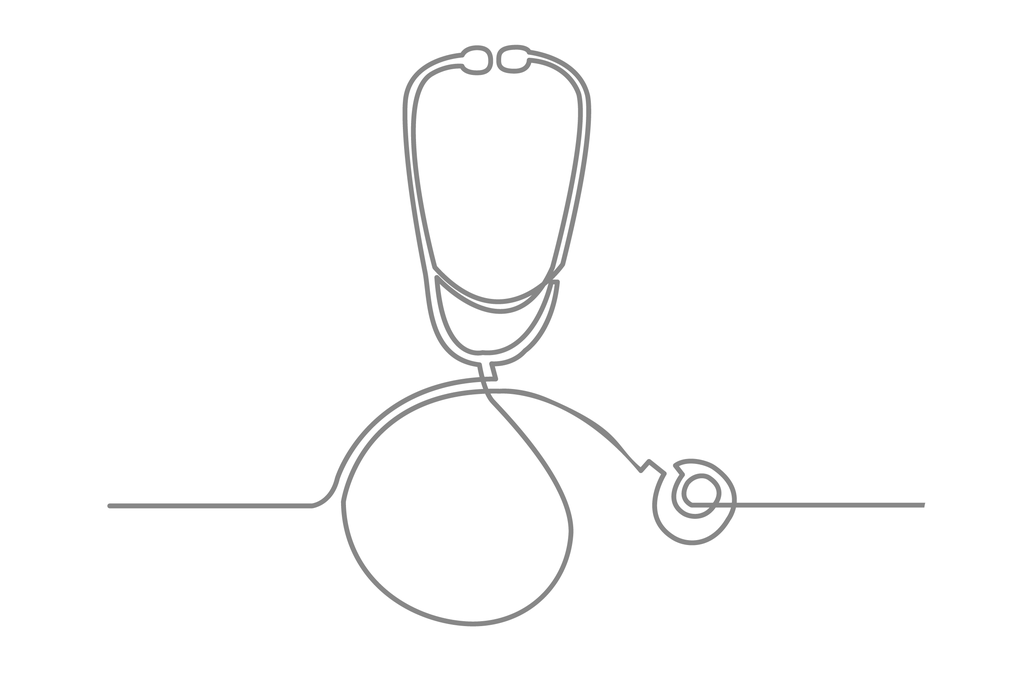

#### Predictor: Access to health services

**Summary**

Metric: Ratio of population per primary care physician

|  | Autauga, Alabama |
| --- | --- |
| Ratio of people to physicians | 2235:1 |
| Data quality | Strong |

**Source:** US Department of Health and Human Services, Health Resources and Services Administration, Area Health Resources File, 2020-21 (via County Health Rankings, 2022). (Time period: 2019)

**Detail**

Metric: Ratio of population per primary care physician<sup>+</sup>

|  | Autauga, Alabama |
| --- | --- |
| Ratio of people to physicians | 2235:1 |
| Data quality | Strong |

**Source:** US Department of Health and Human Services, Health Resources and Services Administration, Area Health Resources File, 2020-21 (via County Health Rankings, 2022). (Time period: 2019)  
**Notes:** The ratio represents the number of people served by one primary care physician in a county. It assumes the population is equally distributed across physicians and does not account for actual physician patient load. Missing values are reported for counties with population greater than 2,000 and 0 primary care physicians. The metric does not include nurse practitioners, physician assistants, or other primary care providers who are not physicians. The Confidence Interval for this metric is not applicable.

*Visit here for more details about this predictor.*

#### Predictor: Neonatal health

**Summary**

Metric: Share with low birth weight

|  | Autauga, Alabama |
| --- | --- |
| % Low birth weight | 10.3% |
| Data quality | Weak |

**Source:** Centers for Disease Control and Prevention National Center for Health Statistics, Division of Vital Statistics, Natality data, 2020 (via CDC WONDER). (Time period: 2020)

**Detail**

Metric: Share with low birth weight

|  | Autauga, Alabama |
| --- | --- |
| % Low birth weight | 10.3% |
| Confidence Interval | (9.9%, 10.7%) |
| Data quality | Weak |

**Source:** Centers for Disease Control and Prevention National Center for Health Statistics, Division of Vital Statistics, Natality data, 2020 (via CDC WONDER). (Time period: 2020)  
**Notes:** The share of babies born weighing less than 5 pounds 8 ounces (<2,500 grams) out of all births with available birthweight information.

**More Data**

Metric: Share with low birth weight

|  | Group | Year | Autauga, Alabama |
| --- | --- | --- | --- |
| % Low birth weight | All | 2020 | 10.3% |
| Confidence Interval | All | 2020 | (9.9%, 10.7%) |
| Data quality | All | 2020 | Weak |
| % Low birth weight | Black, Non-Hispanic | 2020 | 16.5% |
| Confidence Interval | Black, Non-Hispanic | 2020 | (15.5%, 17.6%) |
| Data quality | Black, Non-Hispanic | 2020 | Weak |
| % Low birth weight | Hispanic | 2020 | 8.4% |
| Confidence Interval | Hispanic | 2020 | (7.2%, 9.5%) |
| Data quality | Hispanic | 2020 | Weak |
| % Low birth weight | Other Races and Ethnicities | 2020 | 11.5% |
| Confidence Interval | Other Races and Ethnicities | 2020 | (9.0%, 14.0%) |
| Data quality | Other Races and Ethnicities | 2020 | Weak |
| % Low birth weight | White, Non-Hispanic | 2020 | 8.4% |
| Confidence Interval | White, Non-Hispanic | 2020 | (7.9%, 8.8%) |
| Data quality | White, Non-Hispanic | 2020 | Weak |
| % Low birth weight | All | 2018 | 10.1% |
| Confidence Interval | All | 2018 | (9.7%, 10.5%) |
| Data quality | All | 2018 | Weak |
| % Low birth weight | Black, Non-Hispanic | 2018 | 16.0% |
| Confidence Interval | Black, Non-Hispanic | 2018 | (15.0%, 17.0%) |
| Data quality | Black, Non-Hispanic | 2018 | Weak |
| % Low birth weight | Hispanic | 2018 | 6.5% |
| Confidence Interval | Hispanic | 2018 | (5.3%, 7.6%) |
| Data quality | Hispanic | 2018 | Weak |
| % Low birth weight | Other Races and Ethnicities | 2018 | 10.5% |
| Confidence Interval | Other Races and Ethnicities | 2018 | (7.9%, 13.0%) |
| Data quality | Other Races and Ethnicities | 2018 | Weak |
| % Low birth weight | White, Non-Hispanic | 2018 | 8.6% |
| Confidence Interval | White, Non-Hispanic | 2018 | (8.2%, 9.1%) |
| Data quality | White, Non-Hispanic | 2018 | Weak |

**Source:** Centers for Disease Control and Prevention National Center for Health Statistics, Division of Vital Statistics, Natality data, 2018 & 2020 (via CDC WONDER). (Time period: 2018 & 2020)  
**Notes:** The share of babies born weighing less than 5 pounds 8 ounces (<2,500 grams) out of all births with available birthweight information. Race and ethnicity is based on the mother’s characteristics.

*Visit here for more details about this predictor.*

#### Predictor: Environmental quality

**Summary**

Metric: Air quality index

|  | Autauga, Alabama |
| --- | --- |
| Air quality index | 18 |
| Data quality | Strong |

**Source:** US Environmental Protection Agency’s AirToxScreen data, 2018 (based on 2017 National Emissions Inventory data). (Time period: 2017-18)

**Detail**

Metric: Air quality index<sup>+</sup>

|  | Autauga, Alabama |
| --- | --- |
| Air quality index | 18 |
| Data quality | Strong |

**Source:** US Environmental Protection Agency’s AirToxScreen data, 2018 (based on 2017 National Emissions Inventory data). (Time period: 2017-18)  
**Notes:** The index is a linear combination of standardized EPA estimates of air quality carcinogenic, respiratory, and neurological hazards measured at the census tract level. Values are inverted and percentile ranked nationally and range from 0 to 100. The higher the index value, the less exposure to toxins harmful to human health. The Confidence Interval for this metric is not applicable.

**More Data**

Metric: Air quality index<sup>+</sup>

|  | Group | Year | Autauga, Alabama |
| --- | --- | --- | --- |
| Air quality index | All | 2018 | 18 |
| Data quality | All | 2018 | Strong |
| Air quality index | Majority Non-White Tracts | 2018 | 13 |
| Data quality | Majority Non-White Tracts | 2018 | Strong |
| Air quality index | Majority White, Non-Hispanic Tracts | 2018 | 18 |
| Data quality | Majority White, Non-Hispanic Tracts | 2018 | Strong |
| Air quality index | No Majority Race/Ethnicity Tracts | 2018 | 26 |
| Data quality | No Majority Race/Ethnicity Tracts | 2018 | Strong |
| Air quality index | All | 2014 | 6 |
| Data quality | All | 2014 | Strong |
| Air quality index | Majority Non-White Tracts | 2014 | 8 |
| Data quality | Majority Non-White Tracts | 2014 | Strong |
| Air quality index | Majority White, Non-Hispanic Tracts | 2014 | 6 |
| Data quality | Majority White, Non-Hispanic Tracts | 2014 | Strong |
| Air quality index | No Majority Race/Ethnicity Tracts | 2014 | NA |
| Data quality | No Majority Race/Ethnicity Tracts | 2014 | NA |

**Source:** Environmental Protection Agency’s National Air Toxics Assessment data, 2014 and AirToxScreen data, 2018 (based on 2014 & 2017 National Emissions Inventory data); US Census Bureau’s 2014 & 2018 5-Year American Community Survey. (Time periods: 2010-14 & 2014-18)  
**Notes:** The index is a linear combination of standardized EPA estimates of air quality carcinogenic, respiratory, and neurological hazards measured at the census tract level. Values are inverted and percentile ranked nationally and range from 0 to 100. The higher the index value, the less exposure to toxins harmful to human health. ‘Majority’ means that at least 60% of residents in a census tract are members of the specified group. ‘High poverty’ means that 40% or more of people in a census tract live in families with incomes below the federal poverty line. The Confidence Interval for this metric is not applicable.

Metric: Air quality index<sup>+</sup>

|  | Group | Year | Autauga, Alabama |
| --- | --- | --- | --- |
| Air quality index | All | 2018 | 18 |
| Data quality | All | 2018 | Strong |
| Air quality index | High Poverty Tracts | 2018 | NA |
| Data quality | High Poverty Tracts | 2018 | NA |
| Air quality index | Not High Poverty Tracts | 2018 | 19 |
| Data quality | Not High Poverty Tracts | 2018 | Strong |
| Air quality index | All | 2014 | 6 |
| Data quality | All | 2014 | Strong |
| Air quality index | High Poverty Tracts | 2014 | NA |
| Data quality | High Poverty Tracts | 2014 | NA |
| Air quality index | Not High Poverty Tracts | 2014 | 6 |
| Data quality | Not High Poverty Tracts | 2014 | Strong |

**Source:** Environmental Protection Agency’s National Air Toxics Assessment data, 2014 and AirToxScreen data, 2018 (based on 2014 & 2017 National Emissions Inventory data); US Census Bureau’s 2014 & 2018 5-Year American Community Survey. (Time periods: 2010-14 & 2014-18)  
**Notes:** The index is a linear combination of standardized EPA estimates of air quality carcinogenic, respiratory, and neurological hazards measured at the census tract level. Values are inverted and percentile ranked nationally and range from 0 to 100. The higher the index value, the less exposure to toxins harmful to human health. ‘Majority’ means that at least 60% of residents in a census tract are members of the specified group. ‘High poverty’ means that 40% or more of people in a census tract live in families with incomes below the federal poverty line. The Confidence Interval for this metric is not applicable.

*Visit here for more details about this predictor.*

#### Predictor: Safety from Trauma

**Summary**

Metric: Deaths due to injury per 100,000 people

|  | Autauga, Alabama |
| --- | --- |
| Trauma | 68.6 |
| Data quality | Strong |

**Source:** National Center for Health Statistics, 2016-20, drawn from the National Vital Statistics System (via County Health Rankings, 2022). (Time period: 2016-20)

**Detail**

Metric: Deaths due to injury per 100,000 people

|  | Autauga, Alabama |
| --- | --- |
| Trauma | 68.6 |
| Confidence Interval | (58.8, 78.3) |
| Data quality | Strong |

**Source:** National Center for Health Statistics, 2016-20, drawn from the National Vital Statistics System (via County Health Rankings, 2022). (Time period: 2016-20)  
**Notes:** Injury deaths is the number of deaths from planned (e.g., homicide or suicide) and unplanned (e.g., motor vehicle deaths) injuries per 100,000 people. Deaths are counted in the county of residence for the person who died, rather than the county where the death occurred. A missing value is reported for counties with fewer than 10 injury deaths in the time frame.

*Visit here for more details about this predictor.*

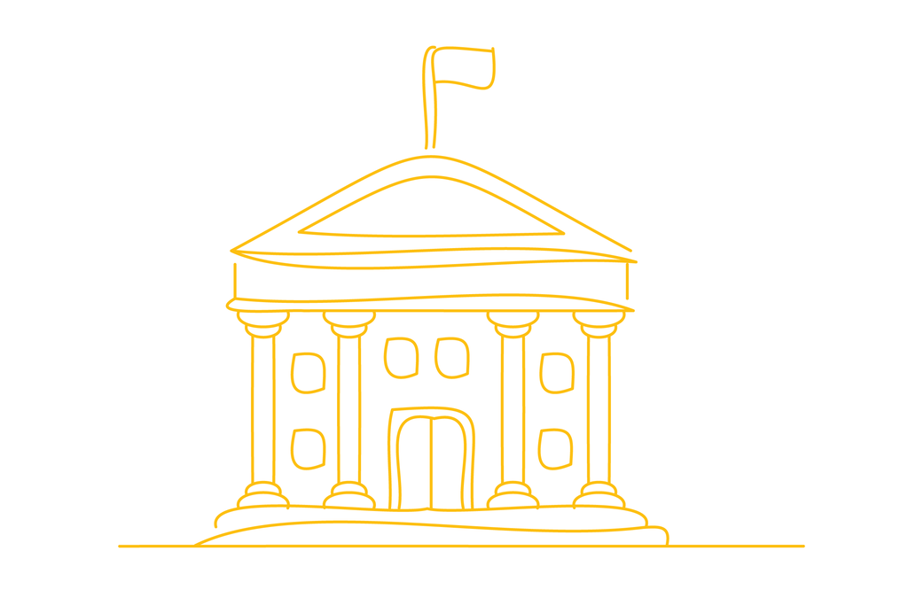

#### Predictor: Political participation

**Summary**

Metric: Share of the voting-age population who turn out to vote

|  | Autauga, Alabama |
| --- | --- |
| % voting | 66.2% |
| Data quality | Strong |

**Source:** Massachusetts Institute of Technology Election Data and Science Lab, 2020; US Census Bureau’s 2020 5-Year American Community Survey Citizen Voting Age Population Special Tabulation. (Time period: 2016-20)

**Detail**

Metric: Share of the voting-age population who turn out to vote<sup>+</sup>

|  | Autauga, Alabama |
| --- | --- |
| % voting | 66.2% |
| Data quality | Strong |

**Source:** Massachusetts Institute of Technology Election Data and Science Lab, 2020; US Census Bureau’s 2020 5-Year American Community Survey Citizen Voting Age Population Special Tabulation. (Time period: 2016-20)  
**Notes:** This metric measures the share of the citizen voting-age population that voted in the most recent presidential election. The Confidence Interval for this metric is not applicable.

**More data**

Metric: Share of the voting-age population who turn out to vote<sup>+</sup>

|  | Year | Autauga, Alabama |
| --- | --- | --- |
| % voting | 2020 | 66.2% |
| Data quality | 2020 | Strong |
| % voting | 2016 | 61.4% |
| Data quality | 2016 | Strong |

**Source:** Massachusetts Institute of Technology Election Data and Science Lab, 2016 & 2020; US Census Bureau’s 2016 & 2020 5-Year American Community Survey Citizen Voting Age Population Special Tabulation. (Time periods: 2012-16 & 2016-20)  
**Notes:** This metric measures the share of the citizen voting-age population that voted in the most recent presidential election. The Confidence Interval for this metric is not applicable.

*Visit here for more details about this predictor.*

#### Predictor: Descriptive Representation

**Detail**

Metric: Ratio of the share of local elected officials of a racial or ethnic group to the share of residents of the same racial or ethnic group. *Part of this metric is shown. See the notes for information on finalizing this metric.*<sup>+</sup>

|  | Autauga, Alabama |
| --- | --- |
| Other Races/Ethnicities | __:4% |
| Black, non-Hispanic | __:20% |
| Hispanic | __:3% |
| White, non-Hispanic | __:73% |

**Source:** US Census Bureau’s 2021 5-Year American Community Survey. (Time period: 2017-21)  
**Notes:** Shown are the share of that racial or ethnic group in your community. The community will need to calculate the missing percentages in order to complete the descriptive representation metric. See the [Planning Guide](https://upward-mobility.urban.org/boosting-upward-mobility-planning-guide-local-action) (pg. 27) on how to calculate the missing percentage. Say that of your 10 elected officials, nine are White, non-Hispanic and your community’s population is half White, non-Hispanic, the metric will read as “90.0%:50.0%.” If the share of local officials is higher than the share of people in the community, then this group is over-represented. If the share of local officials is lower than the share of people in the community, then this group is under-represented. We are presenting this as a ratio of percentages because it provides important context. The quality index reflects the data quality only of the given value. The Confidence Interval for this metric is not applicable.

*Visit here for more details about this predictor.*

#### Predictor: Safety from Crime

**Summary**

Metric: Reported property crimes per 100,000 people and reported violent crimes per 100,000 people

|  | Autauga, Alabama |
| --- | --- |
| Violent crime | 1,047 |
| Property crime | 1,369 |
| Data quality | Strong |

**Source:** Federal Bureau of Investigations (FBI) National Incident Based Reporting System (via Kaplan J (2021). National Incident-Based Reporting System (NIBRS) Data. https://nibrsbook.com/); US Census Bureau’s 2021 1-Year American Community Survey. (Time period: 2021)

**Detail**

Metric: Reported property crimes per 100,000 people and reported violent crimes per 100,000 people<sup>+</sup>

|  | Autauga, Alabama |
| --- | --- |
| Violent crime | 1,047 |
| Property crime | 1,369 |
| Data quality | Strong |

**Source:** Federal Bureau of Investigations (FBI) National Incident Based Reporting System (via Kaplan J (2021). National Incident-Based Reporting System (NIBRS) Data. https://nibrsbook.com/); US Census Bureau’s 2021 1-Year American Community Survey. (Time period: 2021)  
**Notes:** Rates are calculated as the number of reported crimes against property or people per 100,000 people. Although these are the best national data source, communities should use their local data if they are available. The FBI cautions against using NIBRS data to rank or compare locales because there are many factors that cause the nature and type of crime to vary from place to place. The Confidence Interval for this metric is not applicable.

*Visit here for more details about this predictor.*

#### Predictor: Just policing

**Summary**

Metric: Juvenile arrests per 100,000 juveniles

|  | Autauga, Alabama |
| --- | --- |
| Juvenile arrest rate | 41.4 |
| Data quality | Strong |

**Source:** Federal Bureau of Investigations (FBI) National Incident Based Reporting System (via Kaplan J (2021). National Incident-Based Reporting System (NIBRS) Data. https://nibrsbook.com/); US Census Bureau’s 2021 1-Year American Community Survey. (Time period: 2021)

**Detail**

Metric: Juvenile arrests per 100,000 juveniles<sup>+</sup>

|  | Autauga, Alabama |
| --- | --- |
| Juvenile arrest rate | 41.4 |
| Data quality | Strong |

**Source:** Federal Bureau of Investigations (FBI) National Incident Based Reporting System (via Kaplan J (2021). National Incident-Based Reporting System (NIBRS) Data. https://nibrsbook.com/); US Census Bureau’s 2021 1-Year American Community Survey. (Time period: 2021)  
**Notes:** The number of arrests of people aged 10 to 17, for any crime or status offense, per 100,000 people of that age. Because people can be arrested multiple times, the data reports the number of arrests and not people. Although these are the best national data source, communities should use their local data if it is available. The FBI cautions against using NIBRS data to rank or compare locales because there are many factors that cause the nature and type of crime to vary from place to place. The Confidence Interval for this metric is not applicable.

**More Data**

Metric: Juvenile arrests per 100,000 juveniles<sup>+</sup>

|  | Group | Year | Autauga, Alabama |
| --- | --- | --- | --- |
| Juvenile arrest rate | All | 2021 | 41.4 |
| Data quality | All | 2021 | Strong |
| Juvenile arrest rate | Black | 2021 | 127.8 |
| Data quality | Black | 2021 | Strong |
| Juvenile arrest rate | Hispanic | 2021 | 0.0 |
| Data quality | Hispanic | 2021 | Strong |
| Juvenile arrest rate | Other Races and Ethnicities | 2021 | 83.5 |
| Data quality | Other Races and Ethnicities | 2021 | Strong |
| Juvenile arrest rate | White | 2021 | 15.9 |
| Data quality | White | 2021 | Strong |

**Source:** Federal Bureau of Investigations (FBI) National Incident Based Reporting System (via Kaplan J (2021). National Incident-Based Reporting System (NIBRS) Data. https://nibrsbook.com/); US Census Bureau’s 2021 1-Year American Community Survey. (Time period: 2021)  
**Notes:** The number of arrests of people aged 10 to 17, for any crime or status offense, per 100,000 people of that age. Because people can be arrested multiple times, the data reports the number of arrests and not people. Although these are the best national data source, communities should use their local data if it is available. The FBI cautions against using NIBRS data to rank or compare locales because there are many factors that cause the nature and type of crime to vary from place to place. Ethnicity is inconsistently collected and often missing in the data. Those of multiple races are only included in ‘Other Races.’ The Confidence Interval for this metric is not applicable.

*Visit here for more details about this predictor.*

## Additional Notes on Data

### Data Quality

“Strong” indicates that the metric is measured with adequate accuracy and sample size.  
“Marginal” indicates that there are known shortcomings of the data for this metric for this community, and the metric should be used with caution.  
“Weak” indicates that although the metric could be computed for this community, we have serious concerns about how accurately it is measured for this community and do not recommend its use. Instead, we recommend seeking more local data sources for this metric.  
“NA” indicates that the metric value may be suppressed or unavailable and the quality is not applicable.

### Confidence Intervals

Confidence intervals shown are 95 percent.  
* This confidence interval is not available at this time.  
+ A confidence interval is not applicable.  
Lower/Upper bound: The data used to construct this metric do not lend themselves to conventional confidence intervals. The value of the metric shown represents are best estimate; the lower and upper bounds represent alternative estimates of the metric under different assumptions about missing data.

“NC” in fields for confidence intervals or lower/upper bounds means that we are not able to calculate this because the underlying data lack variation.

### Missing and Suppressed Values

“NA” in fields for metric values and data quality values indicates that the data are suppressed due to sample sizes or because that element is not applicable to that community (e.g., no zip code in the county is majority non-white).

Version: 2024-02-13 13:33:51.396516